# A3.3 Multiple testing y aprendizaje por refuerzo

José Ricardo Jáuregui Guevara 608995

## C3.5 Multiple testing

### Paso 1: Carga y visualización inicial del dataset

#### ¿Qué se va a hacer?

Se cargará el dataset NCI60 y se convertirá la matriz de características en un DataFrame para visualizar sus primeras filas.

#### ¿Por qué y para qué se hace?

Este paso permite inspeccionar la estructura de los datos, entender cómo están organizadas las variables y verificar que el dataset se cargó correctamente.

#### Resultados

Se obtiene un DataFrame donde:

- Cada fila representa una observación.
- Cada columna representa una variable (gen).

Al mostrar las primeras filas, se observa que los datos son numéricos y de alta dimensionalidad. Esto confirma que el dataset es adecuado para aplicar técnicas de reducción de dimensionalidad y clustering en pasos posteriores.

```python
import pandas as pd

nci60_data_dict = ISLP.load_data('NCI60')

# The 'data' key in the dictionary contains the features as a NumPy array.
# We convert this array into a pandas DataFrame to use the .head() method.
df_features = pd.DataFrame(nci60_data_dict['data'])
display(df_features.head())

# If you wanted to view the labels, which are already a DataFrame, you could use:
# display(nci60_data_dict['labels'].head())
```

|  | 0 | 1 | 2 | 3 | 4 | 5 | 6 | 7 | 8 | 9 | ... | 6820 | 6821 | 6822 | 6823 | 6824 | 6825 | 6826 | 6827 | 6828 | 6829 |
| --- | --- | --- | --- | --- | --- | --- | --- | --- | --- | --- | --- | --- | --- | --- | --- | --- | --- | --- | --- | --- | --- |
| 0 | 0.300000 | 1.180000 | 0.550000 | 1.140000 | -0.265000 | -7.000000e-02 | 0.350000 | -0.315000 | -0.450000 | -0.654980 | ... | -0.990020 | 0.000000 | 0.030000 | -0.175000 | 0.629981 | -0.030000 | 0.000000 | 0.280000 | -0.340000 | -1.930000 |
| 1 | 0.679961 | 1.289961 | 0.169961 | 0.379961 | 0.464961 | 5.799610e-01 | 0.699961 | 0.724961 | -0.040039 | -0.285019 | ... | -0.270058 | -0.300039 | -0.250039 | -0.535039 | 0.109941 | -0.860039 | -1.250049 | -0.770039 | -0.390039 | -2.000039 |
| 2 | 0.940000 | -0.040000 | -0.170000 | -0.040000 | -0.605000 | 0.000000e+00 | 0.090000 | 0.645000 | 0.430000 | 0.475019 | ... | 0.319981 | 0.120000 | -0.740000 | -0.595000 | -0.270020 | -0.150000 | 0.000000 | -0.120000 | -0.410000 | 0.000000 |
| 3 | 0.280000 | -0.310000 | 0.680000 | -0.810000 | 0.625000 | -1.387779e-17 | 0.170000 | 0.245000 | 0.020000 | 0.095019 | ... | -1.240020 | -0.110000 | -0.160000 | 0.095000 | -0.350019 | -0.300000 | -1.150010 | 1.090000 | -0.260000 | -1.100000 |
| 4 | 0.485000 | -0.465000 | 0.395000 | 0.905000 | 0.200000 | -5.000000e-03 | 0.085000 | 0.110000 | 0.235000 | 1.490019 | ... | 0.554980 | -0.775000 | -0.515000 | -0.320000 | 0.634980 | 0.605000 | 0.000000 | 0.745000 | 0.425000 | 0.145000 |

5 rows × 6830 columns

```python
from sklearn.preprocessing import StandardScaler
from sklearn.decomposition import PCA
from sklearn.cluster import KMeans
import matplotlib.pyplot as plt
import seaborn as sns
```

### Paso 2: Estandarización de los datos

#### ¿Qué se va a hacer?

Se aplicará un proceso de estandarización a los datos para que todas las variables tengan media 0 y desviación estándar 1.

#### ¿Por qué y para qué se hace?

Este paso es importante porque muchos algoritmos de análisis (como PCA y clustering) son sensibles a la escala de los datos. Estandarizar evita que variables con valores más grandes dominen el análisis.

#### Resultados

Se obtiene un nuevo conjunto de datos escalado con las mismas dimensiones que el original:

Esto indica que no se modificó la estructura del dataset, solo la escala de los valores. Ahora los datos están listos para ser utilizados en métodos como PCA o clustering.

```python
scaler = StandardScaler()
df_scaled = scaler.fit_transform(df_features)

print("Scaled data shape:", df_scaled.shape)
```

```
Scaled data shape: (64, 6830)
```

### Paso 3: Reducción de dimensionalidad con PCA

#### ¿Qué se va a hacer?

Se aplicará PCA para reducir los datos a dos componentes principales y se almacenarán en un nuevo DataFrame.

#### ¿Por qué y para qué se hace?

Este paso permite simplificar los datos manteniendo la mayor variabilidad posible, facilitando su visualización en un plano bidimensional.

#### Resultados

```python
pca = PCA(n_components=2)
pca_scores = pca.fit_transform(df_scaled)

# Create a DataFrame for easier plotting
df_pca = pd.DataFrame(data=pca_scores, columns=['PC1', 'PC2'])
display(df_pca.head())
```

|  | PC1 | PC2 |
| --- | --- | --- |
| 0 | 19.838028 | -3.559969 |
| 1 | 23.089208 | -6.448951 |
| 2 | 27.456124 | -2.467763 |
| 3 | 42.816801 | 9.766761 |
| 4 | 55.418549 | 5.204242 |

### Paso 4: Aplicación de K-Means

#### ¿Qué se va a hacer?

Se aplicará el algoritmo K-Means sobre los datos reducidos con PCA para agrupar las observaciones en 4 clusters.

#### ¿Por qué y para qué se hace?

Este paso permite identificar grupos dentro de los datos en un espacio de menor dimensionalidad, facilitando la interpretación y visualización de los resultados.

#### Resultados

Se obtiene un DataFrame con las componentes principales y una nueva columna `Cluster`

Cada observación ahora está asignada a uno de los 4 clusters. Esto permite analizar cómo se agrupan los datos en el espacio reducido generado por PCA.

```python
kmeans = KMeans(n_clusters=4, random_state=42, n_init='auto')
clusters = kmeans.fit_predict(pca_scores)
df_pca['Cluster'] = clusters

display(df_pca.head())
```

|  | PC1 | PC2 | Cluster |
| --- | --- | --- | --- |
| 0 | 19.838028 | -3.559969 | 2 |
| 1 | 23.089208 | -6.448951 | 2 |
| 2 | 27.456124 | -2.467763 | 2 |
| 3 | 42.816801 | 9.766761 | 2 |
| 4 | 55.418549 | 5.204242 | 2 |

### Paso 5: Visualización de clusters

#### ¿Qué se va a hacer?

Se graficarán las dos componentes principales (PC1 y PC2), mostrando los clusters obtenidos con K-Means.

#### ¿Por qué y para qué se hace?

Este paso permite visualizar cómo se agrupan los datos en el espacio reducido y evaluar si los clusters están bien separados.

#### Resultados

Se obtiene una gráfica de dispersión donde cada punto representa una observación y su color indica el cluster asignado.

Se observa la formación de cuatro grupos en el espacio de PCA. Algunos clusters pueden estar claramente separados, mientras que otros pueden presentar cierto solapamiento, lo que indica que la separación no es perfecta pero sí refleja cierta estructura en los datos.

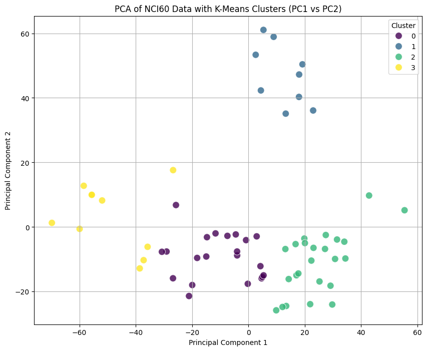

```python
plt.figure(figsize=(10, 8))
sns.scatterplot(x='PC1', y='PC2', hue='Cluster', data=df_pca, palette='viridis', s=100, alpha=0.8)
plt.title('PCA of NCI60 Data with K-Means Clusters (PC1 vs PC2)')
plt.xlabel('Principal Component 1')
plt.ylabel('Principal Component 2')
plt.grid(True)
plt.show()
```

### Paso 6: Identificación de variables significativas entre clusters

#### ¿Qué se va a hacer?

Se realizarán pruebas estadísticas (t-test) para comparar las variables entre dos clusters específicos (Cluster 1 y Cluster 2).

#### ¿Por qué y para qué se hace?

Este paso permite identificar qué variables presentan diferencias significativas entre clusters, lo que ayuda a entender qué características son responsables de la separación observada.

#### Resultados

Se evalúan todas las variables del dataset comparando ambos clusters:

- Se utiliza un nivel de significancia de 0.05.
- Para cada variable se calcula un p-value y un estadístico t.

Se obtiene una tabla con las variables significativas, ordenadas por p-value

Las variables con p-value menor a 0.05 indican diferencias estadísticamente significativas entre los clusters.

Esto permite interpretar el clustering desde un punto de vista estadístico, identificando qué variables contribuyen más a la diferenciación entre grupos.

```python
from scipy.stats import ttest_ind

# Filter df_pca to get indices for Cluster 1 and Cluster 2
indices_cluster1 = df_pca[df_pca['Cluster'] == 1].index
indices_cluster2 = df_pca[df_pca['Cluster'] == 2].index

# Select the original feature data for each cluster
data_cluster1 = df_features.loc[indices_cluster1]
data_cluster2 = df_features.loc[indices_cluster2]

significant_variables = []
alpha = 0.05 # Significance level

print(f"Performing t-tests between Cluster 1 (n={len(data_cluster1)}) and Cluster 2 (n={len(data_cluster2)}) for all {df_features.shape[1]} variables.\n")

# Perform t-test for each variable
for column in df_features.columns:
    # Extract data for the current variable for both clusters
    sample1 = data_cluster1[column]
    sample2 = data_cluster2[column]

    # Perform independent t-test
    stat, p_value = ttest_ind(sample1, sample2, equal_var=False) # Welch's t-test assuming unequal variances

    # Check for significance
    if p_value < alpha:
        significant_variables.append({'Variable': column, 'p-value': p_value, 't-statistic': stat})


# Convert results to DataFrame for better display
significant_df = pd.DataFrame(significant_variables).sort_values(by='p-value').reset_index(drop=True)

if not significant_df.empty:
    print(f"Found {len(significant_df)} significant variables between Cluster 1 and Cluster 2 (p < {alpha}):")
    display(significant_df)
else:
    print(f"No significant variables found between Cluster 1 and Cluster 2 at p < {alpha}.")
```

```
Performing t-tests between Cluster 1 (n=9) and Cluster 2 (n=24) for all 6830 variables.

Found 2584 significant variables between Cluster 1 and Cluster 2 (p < 0.05):
```

|  | Variable | p-value | t-statistic |
| --- | --- | --- | --- |
| 0 | 4326 | 4.737306e-15 | 17.245508 |
| 1 | 4061 | 9.813576e-14 | 12.611483 |
| 2 | 4354 | 1.703978e-13 | 12.487918 |
| 3 | 4315 | 3.502574e-12 | 12.185250 |
| 4 | 4299 | 6.301230e-12 | 11.250971 |
| ... | ... | ... | ... |
| 2579 | 3416 | 4.958079e-02 | -2.217552 |
| 2580 | 2826 | 4.966106e-02 | 2.130262 |
| 2581 | 5902 | 4.971902e-02 | -2.156016 |
| 2582 | 2410 | 4.982272e-02 | -2.204768 |
| 2583 | 4528 | 4.994849e-02 | 2.251049 |

2584 rows × 3 columns

### Paso 7: Simulación de lanzamientos de moneda

#### ¿Qué se va a hacer?

Se simularán múltiples experimentos de lanzamientos de una moneda para contar cuántas veces aparece “águila” en cada experimento.

#### ¿Por qué y para qué se hace?

Este paso permite modelar un proceso aleatorio y analizar su comportamiento estadístico, lo cual es útil para entender conceptos como media, variabilidad y distribuciones.

#### Resultados

Se obtienen los resultados de 1000 experimentos, donde cada uno consiste en 10 lanzamientos:

- Se registra el número de “águilas” en cada experimento.
- Se calculan estadísticas descriptivas como la media y la desviación estándar.

```python
import numpy as np
import matplotlib.pyplot as plt
import pandas as pd

# Parámetros de la simulación
n_tosses_per_experiment = 10  # Número de lanzamientos por experimento
n_experiments = 1000          # Número total de experimentos

# Realizar la simulación
# np.random.randint(0, 2, size=(n_experiments, n_tosses_per_experiment))
# genera una matriz de 1000x10 donde cada elemento es 0 (sol) o 1 (aguila).
# .sum(axis=1) suma los 1s (aguilas) para cada uno de los 1000 experimentos.
results_aguila_counts = np.random.randint(0, 2, size=(n_experiments, n_tosses_per_experiment)).sum(axis=1)

print(f"Resultados de los primeros 10 experimentos (número de águilas): {results_aguila_counts[:10]}")
print(f"Media de águilas por experimento: {np.mean(results_aguila_counts):.2f}")
print(f"Desviación estándar: {np.std(results_aguila_counts):.2f}")
```

```
Resultados de los primeros 10 experimentos (número de águilas): [5 4 2 6 4 2 4 5 5 5]
Media de águilas por experimento: 5.08
Desviación estándar: 1.59
```

### Paso 8: Visualización de la distribución de resultados

#### ¿Qué se va a hacer?

Se graficará un histograma del número de “águilas” obtenidas en los experimentos.

#### ¿Por qué y para qué se hace?

Este paso permite observar la distribución de los resultados y comparar su forma con la esperada en un proceso aleatorio (distribución binomial).

#### Resultados

Se obtiene un histograma donde:

- El eje X representa el número de “águilas” (de 0 a 10).
- El eje Y representa la frecuencia de ocurrencia.

Se observa una distribución aproximadamente simétrica centrada alrededor de 5, lo cual es consistente con una moneda justa. La mayor concentración de valores se encuentra cerca del promedio, mientras que los extremos (0 o 10 águilas) son menos frecuentes.

Esto confirma que los resultados siguen el comportamiento esperado de un experimento aleatorio con probabilidad uniforme.

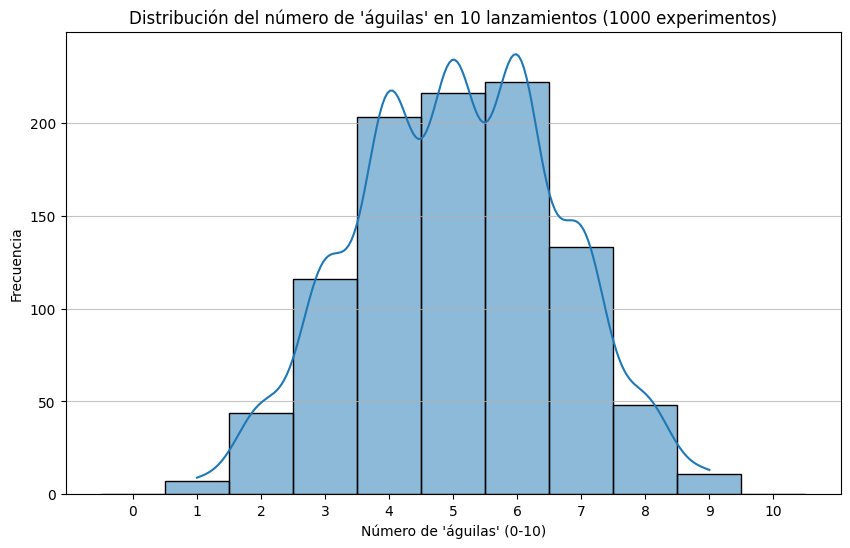

```python
plt.figure(figsize=(10, 6))
sns.histplot(results_aguila_counts, bins=np.arange(0, n_tosses_per_experiment + 2) - 0.5, kde=True, stat='count')
plt.title('Distribución del número de \'águilas\' en 10 lanzamientos (1000 experimentos)')
plt.xlabel('Número de \'águilas\' (0-10)')
plt.ylabel('Frecuencia')
plt.xticks(np.arange(0, n_tosses_per_experiment + 1))
plt.grid(axis='y', alpha=0.75)
plt.show()
```

### Paso 9: Tabla de frecuencias de resultados

#### ¿Qué se va a hacer?

Se calcularán las frecuencias absolutas y relativas del número de “águilas” obtenidas en los experimentos.

#### ¿Por qué y para qué se hace?

Este paso permite cuantificar la distribución observada y compararla con el comportamiento esperado de una distribución probabilística.

#### Resultados

Se obtiene una tabla con:

Se observa que los valores cercanos a 5 tienen mayor frecuencia, mientras que los extremos son menos comunes. La frecuencia relativa confirma que los resultados siguen una distribución aproximadamente binomial, coherente con un experimento de lanzamientos de moneda.

```python
# Calcular las frecuencias
frequencies = pd.Series(results_aguila_counts).value_counts().sort_index()

# Crear un DataFrame para la tabla
results_df = pd.DataFrame({
    'Número de Águilas': frequencies.index,
    'Frecuencia': frequencies.values,
    'Frecuencia Relativa': frequencies.values / n_experiments
})

display(results_df)
```

|  | Número de Águilas | Frecuencia | Frecuencia Relativa |
| --- | --- | --- | --- |
| 0 | 1 | 7 | 0.007 |
| 1 | 2 | 44 | 0.044 |
| 2 | 3 | 116 | 0.116 |
| 3 | 4 | 203 | 0.203 |
| 4 | 5 | 216 | 0.216 |
| 5 | 6 | 222 | 0.222 |
| 6 | 7 | 133 | 0.133 |
| 7 | 8 | 48 | 0.048 |
| 8 | 9 | 11 | 0.011 |

### Paso 10: Corrección por pruebas múltiples

#### ¿Qué se va a hacer?

Se ajustarán los p-values obtenidos anteriormente utilizando métodos de corrección por pruebas múltiples: Bonferroni y Holm.

#### ¿Por qué y para qué se hace?

Cuando se realizan muchas pruebas estadísticas, aumenta la probabilidad de encontrar resultados significativos por azar. Estas correcciones reducen ese riesgo, haciendo el análisis más confiable.

#### Resultados

Se obtiene un DataFrame con los p-values originales y los ajustados. Además, se reporta el número de variables que siguen siendo significativas después de cada corrección:

Se observa que el número de variables significativas disminuye tras la corrección, especialmente con Bonferroni, que es más conservador. Esto indica que algunas variables inicialmente significativas podrían haber sido falsos positivos.

```python
from statsmodels.stats.multitest import multipletests

# Extraer los p-values del DataFrame de variables significativas
p_values = significant_df['p-value'].values

# Ajuste de Bonferroni
reject_bonferroni, p_values_bonferroni, alphac_bonferroni, alphacSidak_bonferroni = multipletests(p_values, alpha=alpha, method='bonferroni')
significant_df['p-value_Bonferroni'] = p_values_bonferroni

# Ajuste de Holm
reject_holm, p_values_holm, alphac_holm, alphacSidak_holm = multipletests(p_values, alpha=alpha, method='holm')
significant_df['p-value_Holm'] = p_values_holm

print("DataFrame con p-values ajustados (primeras 10 filas):")
display(significant_df[['Variable', 'p-value', 'p-value_Bonferroni', 'p-value_Holm']].head(10))

print(f"\nNúmero de variables significativas con Bonferroni (p < {alpha}): {sum(reject_bonferroni)}")
print(f"Número de variables significativas con Holm (p < {alpha}): {sum(reject_holm)}")
```

```
DataFrame con p-values ajustados (primeras 10 filas):
```

|  | Variable | p-value | p-value_Bonferroni | p-value_Holm |
| --- | --- | --- | --- | --- |
| 0 | 4326 | 4.737306e-15 | 1.224120e-11 | 1.224120e-11 |
| 1 | 4061 | 9.813576e-14 | 2.535828e-10 | 2.534847e-10 |
| 2 | 4354 | 1.703978e-13 | 4.403080e-10 | 4.399672e-10 |
| 3 | 4315 | 3.502574e-12 | 9.050651e-09 | 9.040143e-09 |
| 4 | 4299 | 6.301230e-12 | 1.628238e-08 | 1.625717e-08 |
| 5 | 5940 | 9.628282e-12 | 2.487948e-08 | 2.483134e-08 |
| 6 | 4242 | 2.434328e-11 | 6.290305e-08 | 6.275699e-08 |
| 7 | 4060 | 3.019904e-11 | 7.803433e-08 | 7.782293e-08 |
| 8 | 4278 | 3.096713e-11 | 8.001906e-08 | 7.977133e-08 |
| 9 | 3975 | 3.860157e-11 | 9.974645e-08 | 9.939903e-08 |

```
Número de variables significativas con Bonferroni (p < 0.05): 334
Número de variables significativas con Holm (p < 0.05): 345
```

## C3.6 Aprendizaje por refuerzo

### Paso 1: Creación del entorno

#### ¿Qué se va a hacer?

Se creará el entorno CartPole-v1 utilizando la librería Gymnasium y se obtendrá la observación inicial.

#### ¿Por qué y para qué se hace?

Este paso permite inicializar el entorno de simulación donde se desarrollará el aprendizaje por refuerzo. También permite conocer el espacio de observaciones y acciones disponibles.

#### Resultados

Se obtiene la siguiente información del entorno:

- **Observation Space:** describe las variables del estado (posición, velocidad, ángulo, etc.).
- **Action Space:** indica las acciones posibles (mover a la izquierda o derecha).
- **Initial Observation:** valores iniciales del sistema.

Esto confirma que el entorno fue creado correctamente y está listo para interactuar con un agente.

```python
import gymnasium as gym

# Create the CartPole-v1 environment
env = gym.make('CartPole-v1')

# Reset the environment to get initial observation and info
observation, info = env.reset()

print(f"Observation Space: {env.observation_space}")
print(f"Action Space: {env.action_space}")
print(f"Initial Observation: {observation}")
```

```
Observation Space: Box([-4.8               -inf -0.41887903        -inf], [4.8               inf 0.41887903        inf], (4,), float32)
Action Space: Discrete(2)
Initial Observation: [ 0.02902161  0.03844704  0.01889184 -0.03473281]
```

### Paso 2: Configuración de entorno gráfico

#### ¿Qué se va a hacer?

Se iniciará un display virtual para permitir la renderización gráfica del entorno.

#### ¿Por qué y para qué se hace?

Este paso es necesario cuando se trabaja en entornos sin interfaz gráfica (como servidores o notebooks remotos), ya que permite visualizar simulaciones que requieren renderizado.

#### Resultados

Se inicia correctamente un display virtual con resolución definida.

Esto permite ejecutar y visualizar el entorno CartPole sin necesidad de una pantalla física, habilitando la renderización de los episodios.

```python
from pyvirtualdisplay import Display

# Define and initialize a virtual display
virtual_display = Display(visible=0, size=(1400, 900))
virtual_display.start()

print("Virtual display started.")
```

```
Virtual display started.
```

### Paso 3: Visualización del entorno

#### ¿Qué se va a hacer?

Se renderizará el entorno CartPole-v1 en formato de imagen para observar su estado visual inicial.

#### ¿Por qué y para qué se hace?

Este paso permite entender cómo se representa visualmente el entorno y cómo se verán los estados durante la simulación. Es útil para depuración y para interpretar el comportamiento del agente.

#### Resultados

Se obtiene una imagen (frame) del entorno que representa el estado inicial del sistema.

- La observación visual es una matriz de píxeles (RGB).
- Se muestra la forma del arreglo (alto, ancho, canales).
- Se confirma el espacio de acciones y observaciones.

```
Visual Observation (first few pixels):
[255 255 255]
Visual Observation Shape: (400, 600, 3)
Action Space: Discrete(2)
Observation Space: Box([-4.8               -inf -0.41887903        -inf], [4.8               inf 0.41887903        inf], (4,), float32)
```

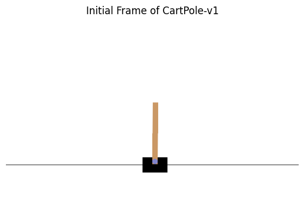

```python
import matplotlib.pyplot as plt

# Create the CartPole-v1 environment with rgb_array render mode
env_visual = gym.make('CartPole-v1', render_mode='rgb_array')

# Reset the environment to get initial observation and info (state observation)
observation_state, info = env_visual.reset()

# Get the visual frame (rgb_array)
frame = env_visual.render()

print(f"Visual Observation (first few pixels):\n{frame[0, 0, :]}")
print(f"Visual Observation Shape: {frame.shape}")
print(f"Action Space: {env_visual.action_space}")
print(f"Observation Space: {env_visual.observation_space}")

# Show the initial frame
plt.imshow(frame)
plt.title("Initial Frame of CartPole-v1")
plt.axis('off')
plt.show()

# Close the environment
env_visual.close()
```

### Paso 4: Inicialización del entorno para interacción

#### ¿Qué se va a hacer?

Se creará un nuevo entorno CartPole-v1 preparado para ejecutar acciones y se obtendrá su estado inicial.

#### ¿Por qué y para qué se hace?

Este paso permite separar el entorno de visualización del entorno de interacción, asegurando que se puedan ejecutar acciones sin interferencias. Es necesario para comenzar a simular el comportamiento de un agente.

#### Resultados

Se inicializa correctamente un nuevo entorno y se obtiene la observación inicial:

- Se confirma que el entorno está listo para recibir acciones.
- Se muestra el estado inicial del sistema (posición, velocidad, ángulo, etc.).

Esto indica que el entorno está preparado para comenzar la interacción mediante acciones del agente.

```python
import matplotlib.pyplot as plt

# Create a new CartPole-v1 environment for taking actions
env_action = gym.make('CartPole-v1', render_mode='rgb_array')

# Reset the environment to get initial observation and info
observation, info = env_action.reset()

print("New environment for actions initialized and reset.")
print(f"Initial Observation: {observation}")
```

```
New environment for actions initialized and reset.
Initial Observation: [-0.0491298   0.03929478 -0.02381077  0.00655843]
```

### Paso 5: Ejecución de una acción (izquierda)

#### ¿Qué se va a hacer?

Se ejecutará una acción en el entorno (mover el carrito hacia la izquierda) y se observará el nuevo estado.

#### ¿Por qué y para qué se hace?

Este paso permite entender cómo interactúa un agente con el entorno y cómo cambian las variables del sistema después de una acción.

#### Resultados

Se obtiene información después de ejecutar la acción:

- **Acción:** 0 (mover a la izquierda)
- **Reward:** valor recibido por la acción (generalmente 1 si el episodio continúa)
- **Terminated:** indica si el episodio terminó por fallar
- **Truncated:** indica si el episodio terminó por límite de tiempo

También se muestra un nuevo frame del entorno, donde se observa un ligero cambio en la posición del carrito y el ángulo del poste.

Esto confirma que la acción tuvo efecto sobre el entorno y que el sistema responde dinámicamente a las decisiones del agente.

```
Action taken: 0 (Move Left)
Reward: 1.0
Terminated: False
Truncated: False
```

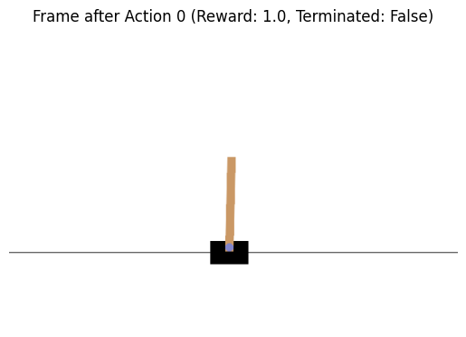

```python
# observation, info = env_action.reset()
# Define action 0 (move left)
action_left = 0

# Take a step in the environment with action_left
observation_left, reward_left, terminated_left, truncated_left, info_left = env_action.step(action_left)

# Get the visual frame after taking the action
frame_left = env_action.render()

print(f"Action taken: {action_left} (Move Left)")
print(f"Reward: {reward_left}")
print(f"Terminated: {terminated_left}")
print(f"Truncated: {truncated_left}")

# Show the new frame
plt.imshow(frame_left)
plt.title(f"Frame after Action {action_left} (Reward: {reward_left}, Terminated: {terminated_left})")
plt.axis('off')
plt.show()
```

### Paso 6: Ejecución de una acción (derecha)

#### ¿Qué se va a hacer?

Se ejecutará otra acción en el entorno, esta vez moviendo el carrito hacia la derecha, y se observará el nuevo estado.

#### ¿Por qué y para qué se hace?

Este paso permite comparar cómo diferentes acciones afectan el entorno, ayudando a entender la dinámica del sistema y cómo un agente puede influir en él.

#### Resultados

Se obtiene información después de ejecutar la acción:

- **Acción:** 1 (mover a la derecha)
- **Reward:** valor recibido por la acción
- **Terminated:** indica si el episodio terminó
- **Truncated:** indica si se alcanzó el límite de tiempo

Esto confirma que el entorno responde de manera distinta según la acción tomada. Finalmente, el entorno se cierra correctamente, liberando recursos.

```
Action taken: 1 (Move Right)
Reward: 0.0
Terminated: True
Truncated: False
```

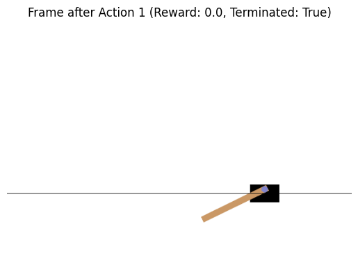

```python
# Define action 1 (move right)
action_right = 1

# Take a step in the environment with action_right
observation_right, reward_right, terminated_right, truncated_right, info_right = env_action.step(action_right)

# Get the visual frame after taking the action
frame_right = env_action.render()

print(f"Action taken: {action_right} (Move Right)")
print(f"Reward: {reward_right}")
print(f"Terminated: {terminated_right}")
print(f"Truncated: {truncated_right}")

# Show the new frame
plt.imshow(frame_right)
plt.title(f"Frame after Action {action_right} (Reward: {reward_right}, Terminated: {terminated_right})")
plt.axis('off')
plt.show()

# It's good practice to close the environment when you're done with it
env_action.close()
```

### Paso 7: Simulación con acciones aleatorias

#### ¿Qué se va a hacer?

Se ejecutará una simulación de 200 pasos en el entorno, donde en cada paso se tomará una acción aleatoria.

#### ¿Por qué y para qué se hace?

Este paso permite observar el comportamiento del entorno sin un agente inteligente, estableciendo una referencia base. También ayuda a entender cómo evoluciona el sistema con decisiones no optimizadas.

#### Resultados

Durante la simulación:

- Se ejecutan 200 pasos en total.
- En cada paso se selecciona una acción aleatoria.
- Se acumula una recompensa total.
- Si el episodio termina, el entorno se reinicia automáticamente.

Al final se obtiene:

```python
import numpy as np

# Create a new environment for the 200-step simulation
env_simulation = gym.make('CartPole-v1', render_mode='rgb_array')

# Reset the environment to get initial observation
observation, info = env_simulation.reset()

total_reward = 0
frames = []
num_steps = 200

print(f"Starting simulation for {num_steps} steps...")

for i in range(num_steps):
    # Render the current frame and add to list
    frames.append(env_simulation.render())

    # Take a random action
    action = env_simulation.action_space.sample()

    # Perform the action in the environment
    observation, reward, terminated, truncated, info = env_simulation.step(action)
    total_reward += reward

    # If the episode terminated or truncated, reset the environment
    # This allows the simulation to continue for 200 steps in total
    # even if an individual episode ends earlier.
    if terminated or truncated:
        observation, info = env_simulation.reset()

print(f"Simulation finished. Total reward over {num_steps} steps: {total_reward}")

# Close the environment after the simulation
env_simulation.close()
```

```
Starting simulation for 200 steps...
Simulation finished. Total reward over 200 steps: 200.0
```

### Paso 8: Generación y visualización del video

#### ¿Qué se va a hacer?

Se generará un video a partir de los frames obtenidos durante la simulación y se mostrará dentro del entorno de trabajo.

#### ¿Por qué y para qué se hace?

Este paso permite visualizar de manera continua el comportamiento del entorno a lo largo del tiempo, facilitando la interpretación de cómo evoluciona el sistema con acciones aleatorias.

#### Resultados

Se obtiene:

- Un archivo de video (formato .mp4) con la simulación completa.
- Visualización del video directamente en el notebook.

En el video se observa:

- El carrito moviéndose de manera aleatoria.
- El poste perdiendo el equilibrio con frecuencia.
- Reinicios del entorno cuando el episodio termina.

Esto confirma que las acciones aleatorias no son suficientes para mantener el sistema estable, evidenciando la necesidad de aplicar algoritmos de aprendizaje por refuerzo para mejorar el desempeño.

```python
import imageio
from pathlib import Path
import base64
from IPython.display import display, HTML # Explicitly import display

video_path = Path('cartpole_random_actions.mp4')

# Save frames as a video
# Use 'fps' to control the playback speed (frames per second)
imageio.mimsave(video_path, frames, fps=30)

print(f"Video saved to {video_path}")

# Display the video in the notebook
video_base64 = base64.b64encode(video_path.read_bytes()).decode('ascii')
html_video = f"""
<video width="640" height="480" controls>
    <source src="data:video/mp4;base64,{video_base64}" type="video/mp4">
    Your browser does not support the video tag.
</video>
"""

display(HTML(html_video))
print("Video displayed in the notebook.")
```

```
WARNING:imageio_ffmpeg:IMAGEIO FFMPEG_WRITER WARNING: input image is not divisible by macro_block_size=16, resizing from (600, 400) to (608, 400) to ensure video compatibility with most codecs and players. To prevent resizing, make your input image divisible by the macro_block_size or set the macro_…
```

```
Video saved to cartpole_random_actions.mp4
```

[video not shown]

```
Video displayed in the notebook.
```

### Paso 9: Simulación por episodios

#### ¿Qué se va a hacer?

Se ejecutarán múltiples episodios (1000) en el entorno, donde en cada uno se tomarán acciones aleatorias hasta que el episodio termine.

#### ¿Por qué y para qué se hace?

Este paso permite analizar el desempeño del sistema a lo largo de muchos episodios y observar la variabilidad en las recompensas obtenidas. Es útil para establecer una línea base antes de aplicar algoritmos de aprendizaje.

#### Resultados

Se obtiene una lista con la recompensa total de cada episodio:

- Se ejecutan 1000 episodios.
- En cada episodio se acumula la recompensa hasta que el sistema falla o se alcanza el límite.
- Se almacenan las recompensas en una lista.

Al finalizar:

- Se tienen 1000 valores de recompensa.
- Cada valor representa qué tan bien se mantuvo el equilibrio en ese episodio.

Se observa que, al usar acciones aleatorias, la mayoría de los episodios tienen recompensas bajas, lo que indica que el sistema falla rápidamente. Esto refuerza la idea de que se necesita un agente entrenado para mejorar el rendimiento.

```python
import gymnasium as gym
import matplotlib.pyplot as plt

# Create a new environment for the simulation
env_episodes = gym.make('CartPole-v1')

episode_rewards = []
num_episodes = 1000

print(f"Starting simulation for {num_episodes} episodes...")

for i in range(num_episodes):
    observation, info = env_episodes.reset()
    terminated = False
    truncated = False
    episode_reward = 0

    while not (terminated or truncated):
        action = env_episodes.action_space.sample()
        observation, reward, terminated, truncated, info = env_episodes.step(action)
        episode_reward += reward

    episode_rewards.append(episode_reward)

print(f"Simulation finished. Collected rewards for {len(episode_rewards)} episodes.")

# Close the environment after the simulation
env_episodes.close()
```

```
Starting simulation for 1000 episodes...
Simulation finished. Collected rewards for 1000 episodes.
```

### Paso 10: Distribución de recompensas por episodio

#### ¿Qué se va a hacer?

Se graficará un histograma de las recompensas totales obtenidas en cada episodio.

#### ¿Por qué y para qué se hace?

Este paso permite analizar la distribución del desempeño del agente aleatorio a lo largo de múltiples episodios, identificando patrones como la frecuencia de recompensas bajas o altas.

#### Resultados

Se obtiene un histograma donde:

- El eje X representa la recompensa total por episodio.
- El eje Y representa la cantidad de episodios.

Se observa que:

- La mayoría de los episodios tienen recompensas bajas.
- Pocos episodios alcanzan recompensas altas.
- La distribución está sesgada hacia valores pequeños.

Esto indica que un agente aleatorio rara vez logra mantener el equilibrio por mucho tiempo, confirmando que no existe una estrategia efectiva en este enfoque. Este resultado sirve como referencia base para comparar con futuros modelos de aprendizaje.

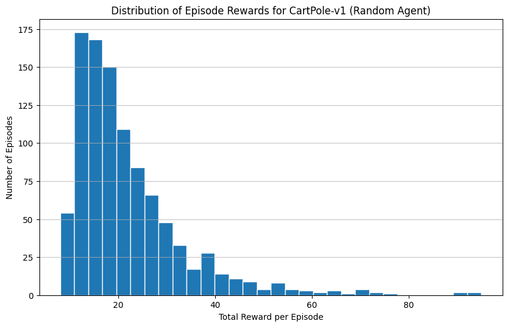

```python
# Plotting the histogram of episode rewards
plt.figure(figsize=(10, 6))
plt.hist(episode_rewards, bins=30, edgecolor='white')
plt.title('Distribution of Episode Rewards for CartPole-v1 (Random Agent)')
plt.xlabel('Total Reward per Episode')
plt.ylabel('Number of Episodes')
plt.grid(axis='y', alpha=0.75)
plt.show()
```

### Paso 11: Discretización del espacio de estados

#### ¿Qué se va a hacer?

Se definirán rangos (bins) para convertir las variables continuas del entorno en estados discretos.

#### ¿Por qué y para qué se hace?

El entorno CartPole maneja valores continuos, pero muchos algoritmos (como Q-learning) requieren estados discretos. Este paso permite transformar el problema en uno manejable mediante tablas.

#### Resultados

Se definen límites para cada variable del estado:

- **Posición del carrito:** [-2.4, 2.4]
- **Velocidad:** [-0.5, 0.5]
- **Ángulo del poste:** [-0.2, 0.2]
- **Velocidad angular:** [-2, 2]

Además, se establecen divisiones (bins):

- Posición: 1 bin
- Velocidad: 1 bin
- Ángulo: 6 bins
- Velocidad angular: 12 bins

Esto genera un espacio de estados discretos donde:

- Las variables más importantes (ángulo y velocidad angular) tienen mayor resolución.
- Las variables menos críticas (posición y velocidad) tienen menor resolución.

Como resultado, el entorno continuo se transforma en un conjunto finito de estados, lo cual permite aplicar métodos de aprendizaje por refuerzo basados en tablas.

First, we'll define the state limits and the number of bins for each observation dimension to discretize the continuous state space. We'll give more bins to angular velocity as suggested.

```python
import numpy as np

# Define state limits (from environment observation space or problem statement)
# Position: -2.4 to 2.4 (cart position)
# Velocity: -0.5 to 0.5 (cart velocity, adjusted as per problem statement)
# Angle: -0.2 to 0.2 (pole angle, rad, approximately -12 to 12 degrees)
# Angular Velocity: -2 to 2 (pole angular velocity, adjusted as per problem statement)

# Note: CartPole-v1's observation space actually has higher velocity/angular velocity limits,
# but the problem statement suggests tighter bounds for discretization.

# State boundaries for discretization
pos_min, pos_max = -2.4, 2.4
vel_min, vel_max = -0.5, 0.5 # Adjusted from problem description
angle_min, angle_max = -0.2, 0.2 # Adjusted from problem description
angular_vel_min, angular_vel_max = -2, 2 # Adjusted from problem description

# Number of bins for each state dimension
# (position, velocity, angle, angular_velocity)
# As per suggestion: (1, 1, 6, 12) - minimal bins for position and velocity
bins = (
    np.linspace(pos_min, pos_max, 1 + 1), # 1 bin means just 2 edges, effectively 2 states if values fall outside
    np.linspace(vel_min, vel_max, 1 + 1), # Effectively 2 states
    np.linspace(angle_min, angle_max, 6 + 1),
    np.linspace(angular_vel_min, angular_vel_max, 12 + 1)
)

# We will use these bins to convert continuous observations into discrete states.
```

### Paso 12: Función de discretización del estado

#### ¿Qué se va a hacer?

Se implementará una función que convierte una observación continua en un estado discreto utilizando los bins definidos previamente.

#### ¿Por qué y para qué se hace?

Este paso es necesario para mapear los valores continuos del entorno a índices discretos, lo que permite utilizar estructuras como tablas Q en algoritmos de aprendizaje por refuerzo.

#### Resultados

La función recibe:

- Una observación del entorno (valores continuos).
- Los bins definidos para cada variable.
- Las dimensiones del espacio de estados.

Y devuelve:

- Una tupla de valores enteros que representan el estado discretizado.

Características del resultado:

- Cada valor corresponde al índice del bin en el que cae cada variable.
- Los índices se ajustan para evitar valores fuera de rango.
- El estado final es una representación discreta del entorno.

```python
def discretize_state(observation, bins, state_dims):
    state = []
    for i, feature_bins in enumerate(bins):
        # Use np.digitize to find the bin index for each observation feature
        # np.digitize returns indices for bins, from 1 to N_bins.
        # For values < feature_bins[0], it returns 0. For values >= feature_bins[-1], it returns len(feature_bins).
        digitized_index = np.digitize(observation[i], feature_bins) - 1

        # Clamp the index to be within the valid range [0, state_dims[i] - 1]
        clamped_index = max(0, min(digitized_index, state_dims[i] - 1))
        state.append(clamped_index)
    return tuple(state)
```

### Paso 13: Inicialización de la Q-table

#### ¿Qué se va a hacer?

Se creará una tabla Q (Q-table) inicializada en ceros, considerando los estados discretizados y el número de acciones posibles.

#### ¿Por qué y para qué se hace?

La Q-table es la estructura principal en Q-learning, donde se almacenan los valores esperados de recompensa para cada combinación de estado y acción. Inicializarla es el primer paso para que el agente pueda aprender.

#### Resultados

Se obtiene una Q-table con dimensiones:

- Dimensiones de estado: determinadas por los bins definidos previamente.
- Dimensión de acción: igual al número de acciones posibles (2 en CartPole).

La forma de la Q-table es:

- `(dim_estado_1, dim_estado_2, dim_estado_3, dim_estado_4, num_acciones)`

Inicialmente todos los valores son 0 y no existe conocimiento previo del entorno.

Esto establece la base para que el agente comience a aprender a partir de la interacción con el entorno, actualizando los valores de la tabla conforme avanza el entrenamiento.

```python
env = gym.make('CartPole-v1') # Create an environment instance to get action space size

# Calculate the size of each dimension for the Q-table
# The number of states in each dimension is num_bins, as digitize returns indices from 0 to num_bins-1
state_dims = [len(b) -1 for b in bins]
num_actions = env.action_space.n

# Initialize Q-table with zeros
q_table_shape = tuple(state_dims + [num_actions])
q_table = np.zeros(q_table_shape)

print(f"Q-table initialized with shape: {q_table.shape}")
env.close()
```

```
Q-table initialized with shape: (1, 1, 6, 12, 2)
```

### Paso 14: Definición de hiperparámetros

#### ¿Qué se va a hacer?

Se establecerán los hiperparámetros necesarios para entrenar el agente utilizando Q-learning.

#### ¿Por qué y para qué se hace?

Los hiperparámetros controlan el proceso de aprendizaje del agente, determinando cómo aprende de la experiencia, cuánto valora el futuro y cómo equilibra exploración y explotación.

#### Resultados

Estos valores establecen el comportamiento del agente durante el entrenamiento, permitiendo que al inicio explore el entorno y posteriormente explote el conocimiento aprendido.

```python
# Q-Learning Hyperparameters
learning_rate = 0.1 # Alpha (α)
discount_factor = 0.99 # Gamma (γ)

# Exploration-Exploitation Parameters (ε-greedy policy)
epsilon = 1.0  # Initial exploration rate
epsilon_min = 0.01 # Minimum exploration rate
epsilon_decay = 0.999 # Decay rate for epsilon

# Training Parameters
num_episodes = 5000 # At least 5,000 episodes
max_steps_per_episode = 500 # Max steps per episode (matches CartPole's default limit)
```

### Paso 15: Entrenamiento con Q-Learning

#### ¿Qué se va a hacer?

Se entrenará un agente utilizando el algoritmo Q-Learning, permitiéndole interactuar con el entorno y actualizar la Q-table en cada paso.

#### ¿Por qué y para qué se hace?

Este paso permite que el agente aprenda una política óptima para maximizar la recompensa, es decir, mantener el poste equilibrado el mayor tiempo posible.

#### Resultados

Durante el entrenamiento:

- Se ejecutan múltiples episodios (5000).
- En cada paso, el agente decide entre explorar (acción aleatoria) o explotar (mejor acción conocida).
- Se actualiza la Q-table usando la ecuación de Bellman.
- Se reduce progresivamente el valor de epsilon (menos exploración, más explotación).

Se obtiene:

- Una lista de recompensas por episodio.
- Una Q-table actualizada con conocimiento del entorno.

Observaciones:

- Al inicio, las recompensas suelen ser bajas debido a la exploración.
- Con el tiempo, las recompensas aumentan conforme el agente aprende.

Esto indica que el agente está aprendiendo una estrategia para mejorar su desempeño en el entorno.

```python
import random

env = gym.make('CartPole-v1') # Create a new environment for training

episode_rewards_q_learning = []

print("Starting Q-Learning training...")

for episode in range(num_episodes):
    observation, info = env.reset()
    current_state = discretize_state(observation, bins, state_dims) # Pass state_dims
    episode_reward = 0

    for step in range(max_steps_per_episode):
        # Epsilon-greedy policy: choose action
        if random.uniform(0, 1) < epsilon:
            action = env.action_space.sample() # Explore: choose random action
        else:
            action = np.argmax(q_table[current_state]) # Exploit: choose best action from Q-table

        # Take action and observe new state and reward
        next_observation, reward, terminated, truncated, info = env.step(action)
        next_state = discretize_state(next_observation, bins, state_dims) # Pass state_dims

        # Update Q-table using the Bellman equation
        old_value = q_table[current_state + (action,)]
        next_max = np.max(q_table[next_state])

        new_value = old_value + learning_rate * (reward + discount_factor * next_max - old_value)
        q_table[current_state + (action,)] = new_value

        current_state = next_state
        episode_reward += reward

        if terminated or truncated:
            break

    episode_rewards_q_learning.append(episode_reward)

    # Decay epsilon
    epsilon = max(epsilon_min, epsilon * epsilon_decay)

    if (episode + 1) % 100 == 0:
        print(f"Episode {episode + 1}/{num_episodes}, Epsilon: {epsilon:.4f}, Reward: {episode_reward}")

env.close()
print("Q-Learning training finished.")
```

```
Starting Q-Learning training...
Episode 100/5000, Epsilon: 0.9048, Reward: 19.0
Episode 200/5000, Epsilon: 0.8186, Reward: 20.0
Episode 300/5000, Epsilon: 0.7407, Reward: 21.0
Episode 400/5000, Epsilon: 0.6702, Reward: 44.0
Episode 500/5000, Epsilon: 0.6064, Reward: 62.0
Episode 600/5000, Epsilon: 0.5486, Reward: 17.0
Episode 700/5000, Epsilon: 0.4964, Reward: 26.0
Episode 800/5000, Epsilon: 0.4491, Reward: 35.0
Episode 900/5000, Epsilon: 0.4064, Reward: 216.0
Episode 1000/5000, Epsilon: 0.3677, Reward: 218.0
Episode 1100/5000, Epsilon: 0.3327, Reward: 174.0
Episode 1200/5000, Epsilon: 0.3010, Reward: 165.0
Episode 1300/5000, Epsilon: 0.2724, Reward: 209.0
Episode 1400/5000, Epsilon: 0.2464, Reward: 195.0
Episode 1500/5000, Epsilon: 0.2230, Reward: 300.0
Episode 1600/5000, Epsilon: 0.2017, Reward: 269.0
Episode 1700/5000, Epsilon: 0.1825, Reward: 217.0
Episode 1800/5000, Epsilon: 0.1652, Reward: 194.0
Episode 1900/5000, Epsilon: 0.1494, Reward: 231.0
Episode 2000/5000, Epsilon: 0.1352, Reward: 227.0
Episode 2100/5000, Epsilon: 0.1223, Reward: 199.0
Episode 2200/5000, Epsilon: 0.1107, Reward: 257.0
Episode 2300/5000, Epsilon: 0.1001, Reward: 178.0
Episode 2400/5000, Epsilon: 0.0906, Reward: 226.0
Episode 2500/5000, Epsilon: 0.0820, Reward: 237.0
Episode 2600/5000, Epsilon: 0.0742, Reward: 257.0
Episode 2700/5000, Epsilon: 0.0671, Reward: 304.0
Episode 2800/5000, Epsilon: 0.0607, Reward: 194.0
Episode 2900/5000, Epsilon: 0.0549, Reward: 206.0
Episode 3000/5000, Epsilon: 0.0497, Reward: 227.0
Episode 3100/5000, Epsilon: 0.0450, Reward: 268.0
Episode 3200/5000, Epsilon: 0.0407, Reward: 178.0
Episode 3300/5000, Epsilon: 0.0368, Reward: 254.0
Episode 3400/5000, Epsilon: 0.0333, Reward: 216.0
Episode 3500/5000, Epsilon: 0.0301, Reward: 184.0
Episode 3600/5000, Epsilon: 0.0273, Reward: 168.0
Episode 3700/5000, Epsilon: 0.0247, Reward: 201.0
Episode 3800/5000, Epsilon: 0.0223, Reward: 224.0
Episode 3900/5000, Epsilon: 0.0202, Reward: 213.0
Episode 4000/5000, Epsilon: 0.0183, Reward: 173.0
Episode 4100/5000, Epsilon: 0.0165, Reward: 205.0
Episode 4200/5000, Epsilon: 0.0150, Reward: 222.0
Episode 4300/5000, Epsilon: 0.0135, Reward: 224.0
Episode 4400/5000, Epsilon: 0.0123, Reward: 235.0
Episode 4500/5000, Epsilon: 0.0111, Reward: 191.0
Episode 4600/5000, Epsilon: 0.0100, Reward: 249.0
Episode 4700/5000, Epsilon: 0.0100, Reward: 259.0
Episode 4800/5000, Epsilon: 0.0100, Reward: 278.0
Episode 4900/5000, Epsilon: 0.0100, Reward: 268.0
Episode 5000/5000, Epsilon: 0.0100, Reward: 262.0
Q-Learning training finished.
```

### Paso 16: Distribución de recompensas (Q-Learning)

#### ¿Qué se va a hacer?

Se graficará un histograma de las recompensas obtenidas por episodio después del entrenamiento con Q-Learning.

#### ¿Por qué y para qué se hace?

Este paso permite evaluar el desempeño del agente entrenado y compararlo con el agente aleatorio, observando si existe una mejora en las recompensas.

#### Resultados

Se obtiene un histograma donde:

- El eje X representa la recompensa total por episodio.
- El eje Y representa la cantidad de episodios.

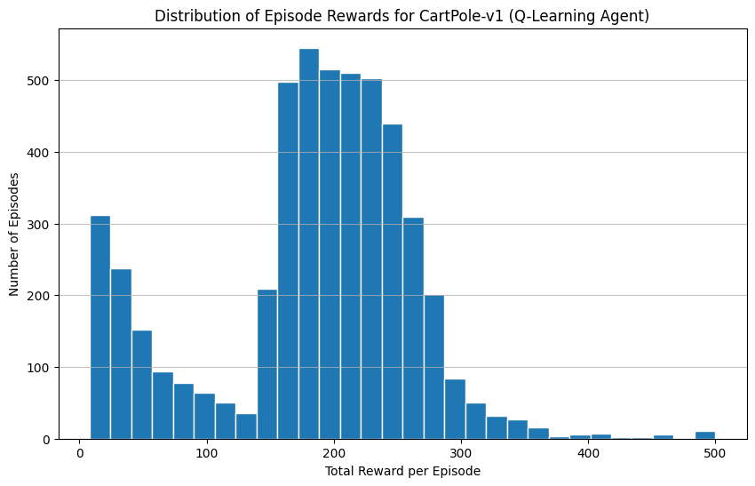

```python
# Plotting the histogram of episode rewards for Q-Learning
plt.figure(figsize=(10, 6))
plt.hist(episode_rewards_q_learning, bins=30, edgecolor='white')
plt.title('Distribution of Episode Rewards for CartPole-v1 (Q-Learning Agent)')
plt.xlabel('Total Reward per Episode')
plt.ylabel('Number of Episodes')
plt.grid(axis='y', alpha=0.75)
plt.show()
```

### Paso 17: Evolución del aprendizaje

#### ¿Qué se va a hacer?

Se graficará la recompensa obtenida en cada episodio a lo largo del entrenamiento.

#### ¿Por qué y para qué se hace?

Este paso permite analizar cómo evoluciona el aprendizaje del agente con el tiempo, identificando si realmente está mejorando su desempeño.

#### Resultados

Se obtiene una gráfica donde:

- El eje X representa el número de episodio.
- El eje Y representa la recompensa total por episodio.

Se observa que:

- Al inicio, las recompensas son bajas y variables.
- Conforme avanzan los episodios, las recompensas tienden a aumentar.
- La curva puede presentar fluctuaciones, pero con una tendencia general al alza.

Esto indica que el agente está aprendiendo progresivamente una mejor estrategia, mejorando su capacidad para mantener el equilibrio del sistema.

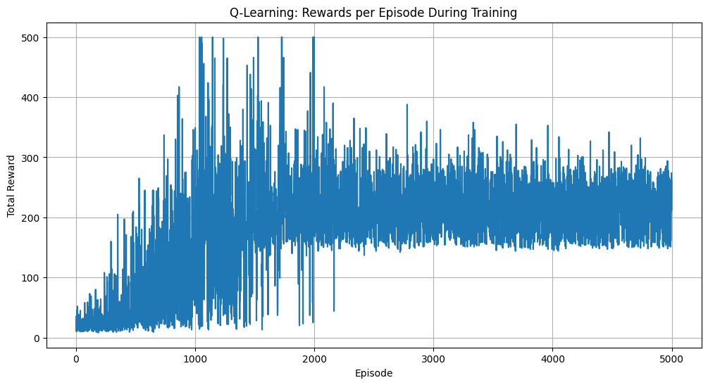

```python
# Plotting rewards per episode
plt.figure(figsize=(12, 6))
plt.plot(episode_rewards_q_learning)
plt.title('Q-Learning: Rewards per Episode During Training')
plt.xlabel('Episode')
plt.ylabel('Total Reward')
plt.grid(True)
plt.show()
```

### Paso 18: Evaluación del agente entrenado

#### ¿Qué se va a hacer?

Se evaluará el agente entrenado ejecutando varios episodios donde únicamente se utilizan las mejores acciones aprendidas (sin exploración).

#### ¿Por qué y para qué se hace?

Este paso permite medir el desempeño real del agente después del entrenamiento, verificando qué tan bien aprendió la política óptima.

#### Resultados

Durante la evaluación:

- Se ejecutan 100 episodios.
- En cada paso se selecciona la mejor acción según la Q-table (explotación).
- Se registra la recompensa total por episodio.

Se obtiene:

Además, se genera un histograma donde:

- La mayoría de los episodios tienen recompensas altas.
- La distribución está concentrada en valores elevados.

```
Evaluating trained Q-learning agent for 100 episodes...
Evaluation finished. Average reward: 214.88
Max reward: 293.0
```

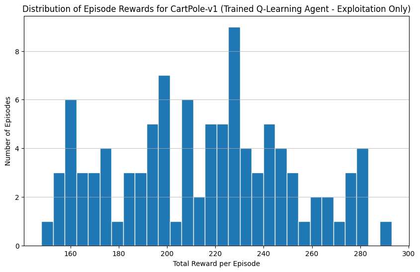

```python
import gymnasium as gym
import numpy as np

# Create a new environment for evaluation
env_eval = gym.make('CartPole-v1')

# We will run for a few episodes to get a sense of performance
num_eval_episodes = 100
max_eval_steps = 500 # Max steps per episode for CartPole-v1

eval_rewards = []

print(f"Evaluating trained Q-learning agent for {num_eval_episodes} episodes...")

for episode in range(num_eval_episodes):
    observation, info = env_eval.reset()
    current_state = discretize_state(observation, bins, state_dims)
    episode_reward = 0

    for step in range(max_eval_steps):
        # Always exploit: choose the action with the highest Q-value
        action = np.argmax(q_table[current_state])

        next_observation, reward, terminated, truncated, info = env_eval.step(action)
        next_state = discretize_state(next_observation, bins, state_dims)

        current_state = next_state
        episode_reward += reward

        if terminated or truncated:
            break

    eval_rewards.append(episode_reward)

print(f"Evaluation finished. Average reward: {np.mean(eval_rewards):.2f}")
print(f"Max reward: {np.max(eval_rewards)}")
env_eval.close()

# Plotting the histogram of episode rewards for Evaluation
plt.figure(figsize=(10, 6))
plt.hist(eval_rewards, bins=30, edgecolor='white')
plt.title('Distribution of Episode Rewards for CartPole-v1 (Trained Q-Learning Agent - Exploitation Only)')
plt.xlabel('Total Reward per Episode')
plt.ylabel('Number of Episodes')
plt.grid(axis='y', alpha=0.75)
plt.show()
```

### Paso 19: Visualización del agente entrenado

#### ¿Qué se va a hacer?

Se generará un video del agente entrenado utilizando la política aprendida (solo explotación) para observar su comportamiento en el entorno.

#### ¿Por qué y para qué se hace?

Este paso permite validar visualmente el desempeño del agente y comprobar si realmente aprendió a mantener el equilibrio del poste.

#### Resultados

Se obtiene:

- Un archivo de video (.mp4) con la simulación del agente.
- Visualización directa del comportamiento en el notebook.

```python
import imageio
from pathlib import Path
import base64
from IPython.display import display, HTML

# Create a new environment for video generation
env_video_ql = gym.make('CartPole-v1', render_mode='rgb_array')

observation, info = env_video_ql.reset()
current_state = discretize_state(observation, bins, state_dims)

frames_ql = []
video_steps = 500 # Simulate for max steps to show learned behavior

print(f"Generating video for trained Q-Learning agent ({video_steps} steps)...")

for i in range(video_steps):
    frames_ql.append(env_video_ql.render())

    # Choose action based on exploitation only
    action = np.argmax(q_table[current_state])

    next_observation, reward, terminated, truncated, info = env_video_ql.step(action)
    current_state = discretize_state(next_observation, bins, state_dims)

    if terminated or truncated:
        # If the episode ends, reset for the next segment of the video
        # Or, if we want to show a single episode until failure, we could break here.
        # For this video, we'll reset to show continuous attempts if it terminates early.
        observation, info = env_video_ql.reset()
        current_state = discretize_state(observation, bins, state_dims)

video_path_ql = Path('cartpole_qlearning_agent.mp4')
imageio.mimsave(video_path_ql, frames_ql, fps=30)

print(f"Video saved to {video_path_ql}")

env_video_ql.close()

# Display the video in the notebook
video_base64_ql = base64.b64encode(video_path_ql.read_bytes()).decode('ascii')
html_video_ql = f"""
<video width="640" height="480" controls>
    <source src="data:video/mp4;base64,{video_base64_ql}" type="video/mp4">
    Your browser does not support the video tag.
</video>
"""

display(HTML(html_video_ql))
print("Video displayed in the notebook.")
```

```
Generating video for trained Q-Learning agent (500 steps)...
```

```
WARNING:imageio_ffmpeg:IMAGEIO FFMPEG_WRITER WARNING: input image is not divisible by macro_block_size=16, resizing from (600, 400) to (608, 400) to ensure video compatibility with most codecs and players. To prevent resizing, make your input image divisible by the macro_block_size or set the macro_…
```

```
Video saved to cartpole_qlearning_agent.mp4
```

[video not shown]

```
Video displayed in the notebook.
```

## Referencias

James, G., Witten, D., Hastie, T., Tibshirani, R., & Taylor, J. (2023). An introduction to statistical learning with applications in Python. Springer. https://doi.org/10.1007/978-3-031-38747-0 Towers, M., Kwiatkowski, A., Terry, J., Balis, J. U., De Cola, G., Deleu, T., Goulão, M., Kallinteris, A., Krimmel, M., KG, A., Perez-Vicente, R., Pierré, A., Schulhoff, S., Tai, J. J., Tan, H., & Younis, O. G. (2024). Gymnasium: A standard interface for reinforcement learning environments. arXiv. https://arxiv.org/abs/2407.17032

Este trabajo fue hecho con el apoyo de Gemini.